# Mode Switching Stats

April 30, 2021

# 1 Data Parsing

## 1.1 Loading Data

```r
# Fetch the trial data.
data.i <- read_csv(
  "data1.csv",
  # I am using col_types to enforce the type of the data, and safely fail
  # if it changes unexpectedly. It isn't really required, but still good
  # practice.
  col_types = cols(
    participantNo = col_factor(),
    task = col_factor(),
    condition = col_factor(),
    forCond = col_factor(),
    mode = col_factor(),
    block = col_number(),
    trialNo = col_double(),
    missCount = col_double(),
    dockingTime = col_double()
  )
) %>%
  # Normalize the condition values.
  mutate(condition = normalize_condition(condition),
         forCond = normalize_condition(forCond))

data.i$methodSwitch = interaction(data.i$mode, data.i$condition)
data.i$methodSwitch = as.factor(data.i$methodSwitch)

data.i.ms <- read_csv("data_ms.csv") %>% mutate(condition = normalize_condition(condition),
         forCond = normalize_condition(forCond))
data.i.ms$block = as.numeric(data.i.ms$block)
```

## 1.3 Outlier Culling

### 1.3.1 Switching Time Outliers

```r
data = data.i %>%
  group_by(task, condition) %>%
  filter(!is_outlier(dockingTime)) %>%
  ungroup()
data.ms = data.i.ms %>% group_by(task, condition) %>%
  filter(!is_outlier(switchingTime)) %>%
  ungroup()
```

## 1.4 Data Aggregation

Removing Blocks 1 & 2 from mode switching trials - we consider these training blocks

```r
data = filter(data, ((task == 'task' & block > 2) | task == 'baseline'))
data$block = as.factor(data$block)
data.ms = filter(data.ms, ((task == 'task' & block > 2) | task == 'baseline'))
data.ms$block = as.factor(data.ms$block)
```

Aggregating the cleaned data

```r
data.group =  summarize(group_by(data, participantNo, task, methodSwitch, condition, mode, block), meanDockTime = mean(dockingTime), meanMisses = mean(missCount)) %>% filter(task == 'task')


data.stats = data %>%
  group_by(task, methodSwitch, condition, mode) %>%
  summarize(mDT = mean(dockingTime), cuDT = ci(dockingTime)[3], clDT = ci(dockingTime)[2], sdDT = sd(dockingTime),
            mMC = mean(missCount), cuMC = ci(missCount)[3], clMC = ci(missCount)[2], sdMC = sd(missCount))

data.stats.block = data %>%
  group_by(task, methodSwitch, block) %>%
  summarize(mDT = mean(dockingTime), cuDT = ci(dockingTime)[3], clDT = ci(dockingTime)[2], sdDT = sd(dockingTime),
            mMC = mean(missCount), cuMC = ci(missCount)[3], clMC = ci(missCount)[2], sdMC = sd(missCount))

data.ms$condition = as.character(data.ms$condition)
data.ms$direction = ifelse(data.ms$cycleType == "A",
                                           paste(toTitleCase(sapply(
                                           strsplit(data.ms$condition, ","), "[", 1
                                           )), "to", toTitleCase(sapply(
                                           strsplit(data.ms$condition, ","), "[", 2
                                           ))),
                                           paste(toTitleCase(sapply(
                                           strsplit(data.ms$condition, ","), "[", 2
                                           )), "to", toTitleCase(sapply(
                                           strsplit(data.ms$condition, ","), "[", 1
                                           ))))
data.ms$condition = as.factor(data.ms$condition)
data.ms$block = as.factor(data.ms$block)
data.ms$participantNo = as.factor(data.ms$participantNo)
data.ms$direction = as.factor(data.ms$direction)
data.ms$location = as.factor(data.ms$location)

data.ms.group = summarize(group_by(data.ms, participantNo, task, condition, block), meanSwitchTime = mean(switchingTime), meanMSTimeB = mean(msTimeB)) %>% filter(task == 'task')

data.ms.dir =
  summarize(group_by(data.ms, participantNo, task, condition, direction, block), meanSwitchTime = mean(switchingTime), meanMSTimeB = mean(msTimeB)) %>% filter(task == 'task')

data.ms.loc =
  summarize(group_by(data.ms, participantNo, task, condition, location, block), meanSwitchTime = mean(switchingTime), meanMSTimeB = mean(msTimeB)) %>% filter(task == 'task')


data.ms.stats = data.ms %>%
  group_by(task, condition) %>%
  summarize(mST = mean(switchingTime), cuST = ci(switchingTime)[3], clST = ci(switchingTime)[2], sdST = sd(switchingTime),
            mMTB = mean(msTimeB), cuMTB = ci(msTimeB)[3], clMTB = ci(msTimeB)[2], sdMTB = sd(msTimeB)) %>% filter(task == 'task')

data.ms.stats.direction = data.ms %>%
  group_by(task, condition, direction, cycleType) %>%
  summarize(mST = mean(switchingTime), cuST = ci(switchingTime)[3], clST = ci(switchingTime)[2], sdST = sd(switchingTime),
            mMTB = mean(msTimeB), cuMTB = ci(msTimeB)[3], clMTB = ci(msTimeB)[2], sdMTB = sd(msTimeB)) %>% filter(task == 'task')

data.ms.stats.direction.block = data.ms %>%
  group_by(task, condition, direction, cycleType, block) %>%
  summarize(mST = mean(switchingTime), cuST = ci(switchingTime)[3], clST = ci(switchingTime)[2], sdST = sd(switchingTime),
            mMTB = mean(msTimeB), cuMTB = ci(msTimeB)[3], clMTB = ci(msTimeB)[2], sdMTB = sd(msTimeB)) %>% filter(task == 'task')

data.ms.stats.block = data.ms %>%
  group_by(task, condition, block) %>%
  summarize(mST = mean(switchingTime), cuST = ci(switchingTime)[3], clST = ci(switchingTime)[2], sdST = sd(switchingTime),
            mMTB = mean(msTimeB), cuMTB = ci(msTimeB)[3], clMTB = ci(msTimeB)[2], sdMTB = sd(msTimeB))%>% filter(task == 'task')

data.ms.stats.loc = data.ms %>%
  group_by(task, condition, location) %>%
  summarize(mST = mean(switchingTime), cuST = ci(switchingTime)[3], clST = ci(switchingTime)[2], sdST = sd(switchingTime),
            mMTB = mean(msTimeB), cuMTB = ci(msTimeB)[3], clMTB = ci(msTimeB)[2], sdMTB = sd(msTimeB))%>% filter(task == 'task')

data.ms.stats.loc2 = data.ms %>%
  group_by(task,  location) %>%
  summarize(mST = mean(switchingTime), cuST = ci(switchingTime)[3], clST = ci(switchingTime)[2], sdST = sd(switchingTime),
            mMTB = mean(msTimeB), cuMTB = ci(msTimeB)[3], clMTB = ci(msTimeB)[2], sdMTB = sd(msTimeB))%>% filter(task == 'task')



lvls = c("Pen to Touch", "Touch to Pen", "Pen to Mouse", "Mouse to Pen", "Mouse to Touch", "Touch to Mouse", "Trackpad to Mouse", "Mouse to Trackpad", "Pen to Trackpad", "Trackpad to Pen", "Trackpad to Touch", "Touch to Trackpad")
data.ms.stats.direction$direction = factor(data.ms.stats.direction$direction, levels=lvls)
```

```r
base = summarize(group_by(data, participantNo, task, condition, mode, block), meanDockTime = mean(dockingTime), meanMisses = mean(missCount), meanWrong = mean(wrongModeCount), meanPos = mean(posMissCount))

mouse = filter(base, mode=='mouse')
touch = filter(base, mode=='touch')
pen = filter(base, mode=='pen')
trackpad = filter(base, mode=='trackpad')
```

# 2 Histograms

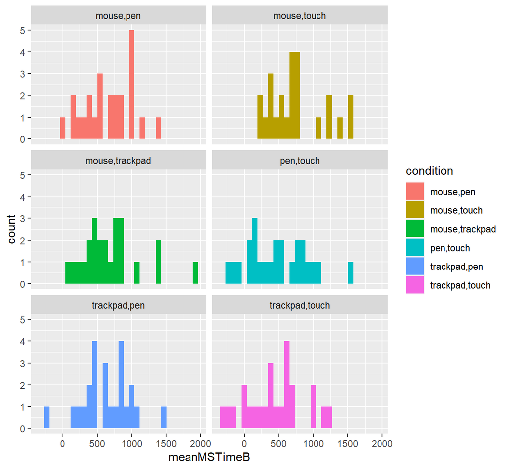

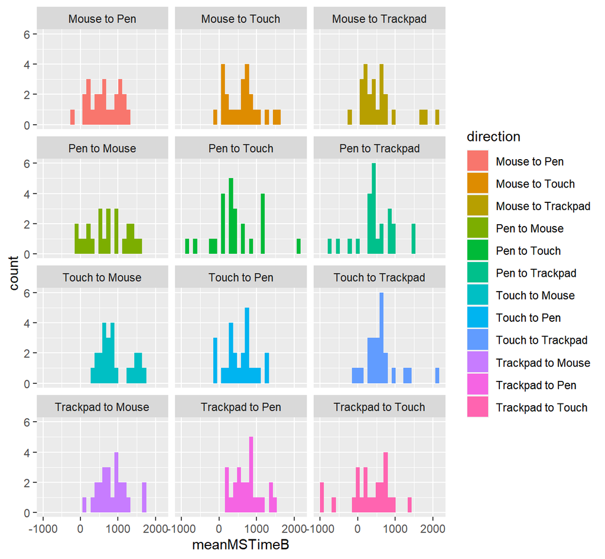

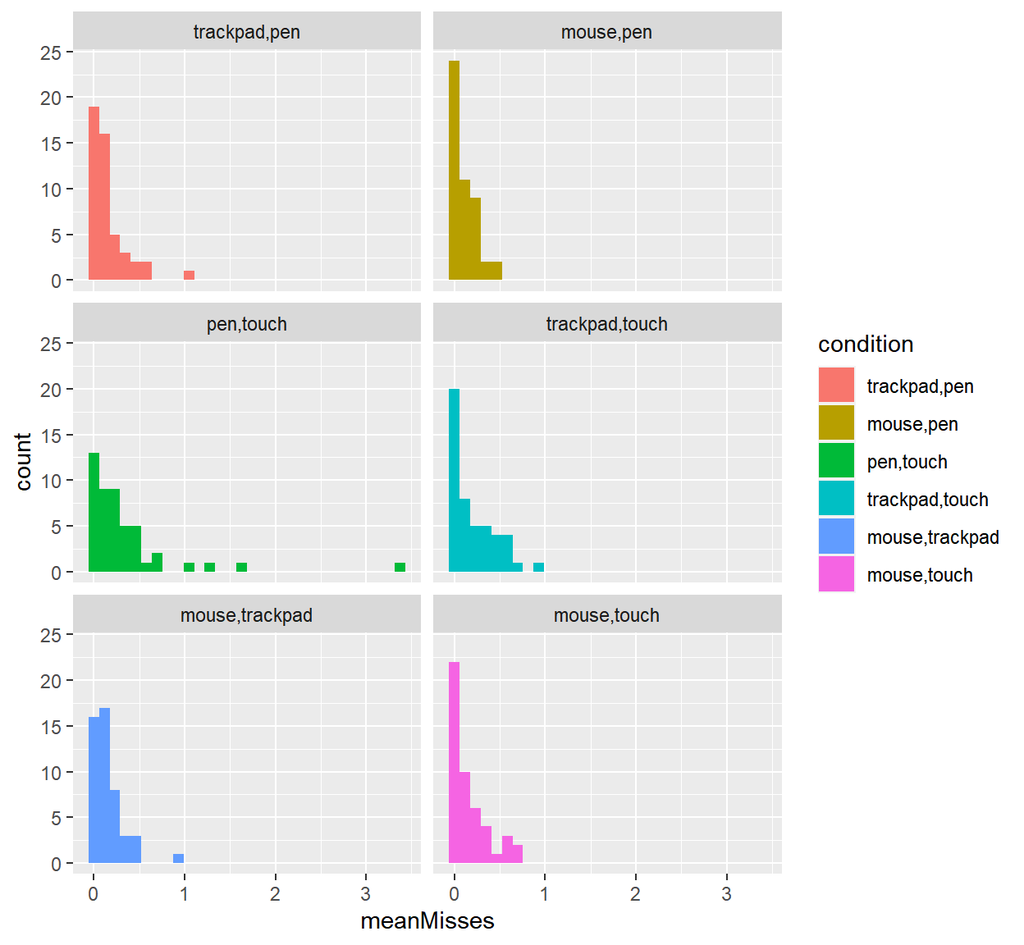

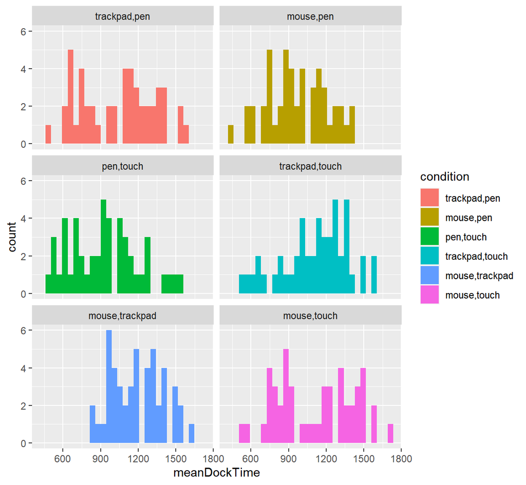

# 3 Docking Time

## 3.1 Mode Switching Task

### 3.1.1 Chart

```r
kable(dplyr::select(filter(data.stats, task == 'task'), task, methodSwitch, mDT, sdDT))
```

| condition | task | methodSwitch | mDT | sdDT |
| --- | --- | --- | --- | --- |
| trackpad,pen | task | pen.trackpad,pen | 876.1406 | 309.2150 |
| trackpad,pen | task | trackpad.trackpad,pen | 1203.1429 | 332.3605 |
| mouse,pen | task | mouse.mouse,pen | 1042.1354 | 316.6614 |
| mouse,pen | task | pen.mouse,pen | 896.8698 | 315.3502 |
| pen,touch | task | pen.pen,touch | 871.8802 | 348.2512 |
| pen,touch | task | touch.pen,touch | 982.1765 | 335.4172 |
| trackpad,touch | task | touch.trackpad,touch | 1043.5052 | 354.5331 |
| trackpad,touch | task | trackpad.trackpad,touch | 1176.5236 | 328.7093 |
| mouse,trackpad | task | mouse.mouse,trackpad | 1157.1361 | 341.2523 |
| mouse,trackpad | task | trackpad.mouse,trackpad | 1229.5916 | 326.7078 |
| mouse,touch | task | mouse.mouse,touch | 1132.0576 | 388.2376 |
| mouse,touch | task | touch.mouse,touch | 1095.0156 | 401.5394 |

### 3.1.2 Graph

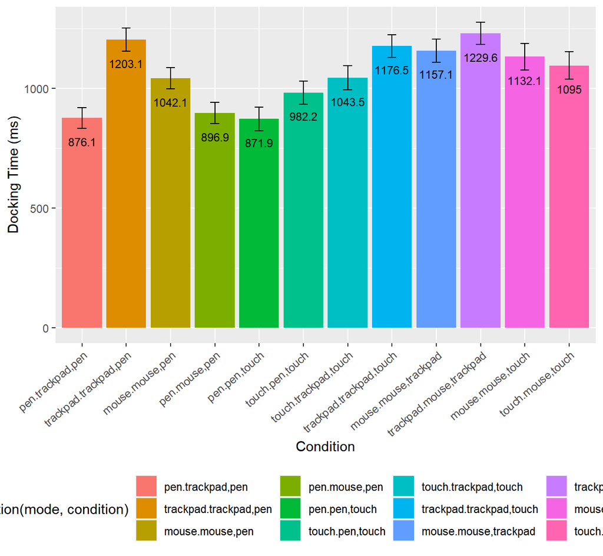

```r
ggplot(data=filter(data.stats, task == 'task'), aes(x=interaction(mode, condition), y=mDT, fill=interaction(mode, condition))) +
  geom_bar(stat="identity") +
  geom_errorbar(aes(ymin = clDT, ymax = cuDT), width = 0.2, size = .5, position = position_dodge(.7)) +
  geom_text(aes(label=round(mDT,digits=1)), size = 3, position = position_dodge(0.7), vjust = 3.2) +
  scale_x_discrete(name="Condition") +
  scale_y_continuous(name="Docking Time (ms)") +
  theme(axis.text.x = element_text(angle = 40, vjust = 1, hjust=1),
        legend.position = 'bottom')
```

Docking time was fastest when switching between touch and pen, and slowest when switching between trackpad and mouse.

## 3.2 Baseline Task

### 3.2.1 Chart

```r
kable(dplyr::select(filter(data.stats, task == 'baseline'), task, condition, mDT, sdDT))
```

| methodSwitch | task | condition | mDT | sdDT |
| --- | --- | --- | --- | --- |
| mouse.mouse,mouse | baseline | mouse,mouse | 1081.4851 | 343.9429 |
| pen.pen,pen | baseline | pen,pen | 824.6596 | 300.7994 |
| touch.touch,touch | baseline | touch,touch | 984.4241 | 366.3211 |
| trackpad.trackpad,trackpad | baseline | trackpad,trackpad | 1195.0123 | 363.3798 |

### 3.2.2 Graph

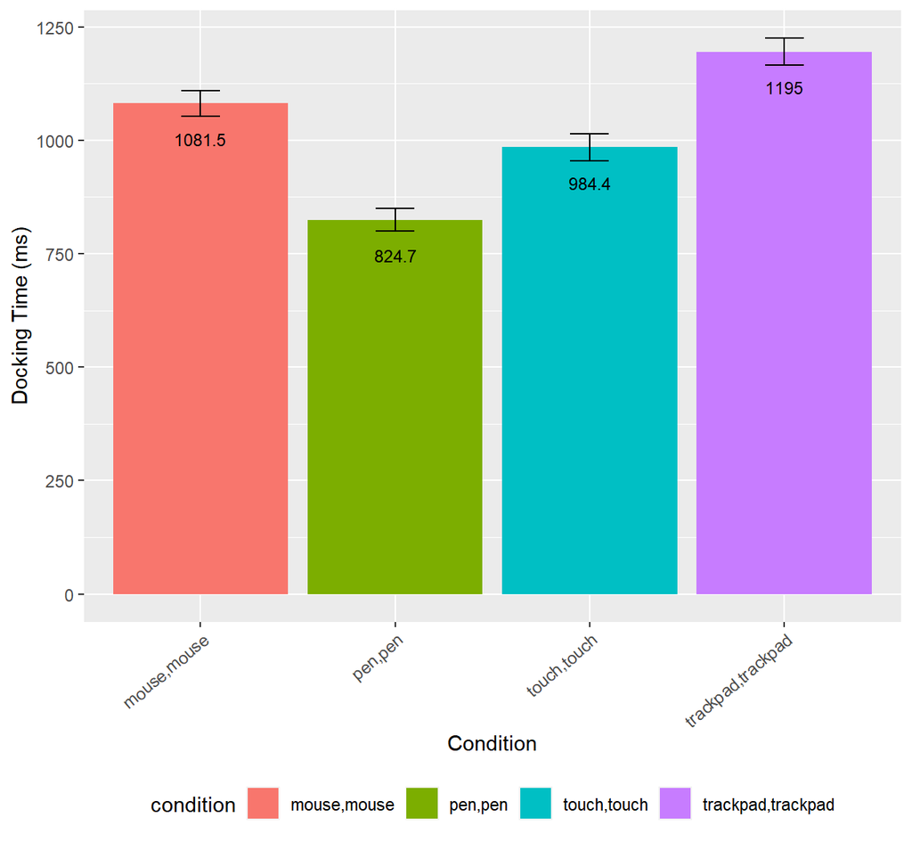

```r
ggplot(data=filter(data.stats, task == 'baseline'), aes(x=condition, y=mDT, fill=condition)) +
  geom_bar(stat="identity") +
  geom_errorbar(aes(ymin = clDT, ymax = cuDT), width = 0.2, size = .5, position = position_dodge(.7)) +
  geom_text(aes(label=round(mDT,digits=1)), size = 3, position = position_dodge(0.7), vjust = 3.2) +
  scale_x_discrete(name="Condition") +
  scale_y_continuous(name="Docking Time (ms)") +
  theme(axis.text.x = element_text(angle = 40, vjust = 1, hjust=1),
        legend.position = 'bottom')
```

## 3.3 Effect of Mode Switching Devices

### 3.3.1 Normality Check

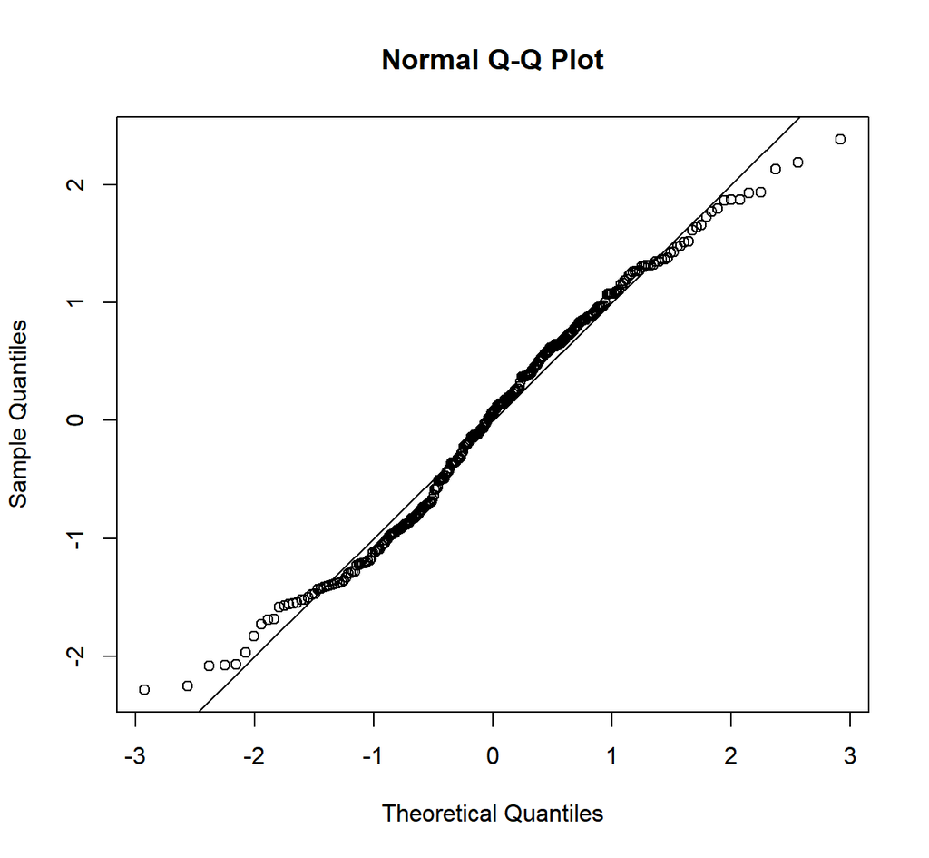

```r
m <- aov(meanDockTime ~ condition*block, data=data.group)
pander(normalCheck(m))
```

Shapiro-Wilk normality test

data: res W = 0.98512, p-value = 0.004424

Shapiro-Wilk normality test: `res`

| Test statistic | P value |
| --- | --- |
| 0.9851 | 0.004424 * * |

### 3.3.2 Box-Cox Transformation

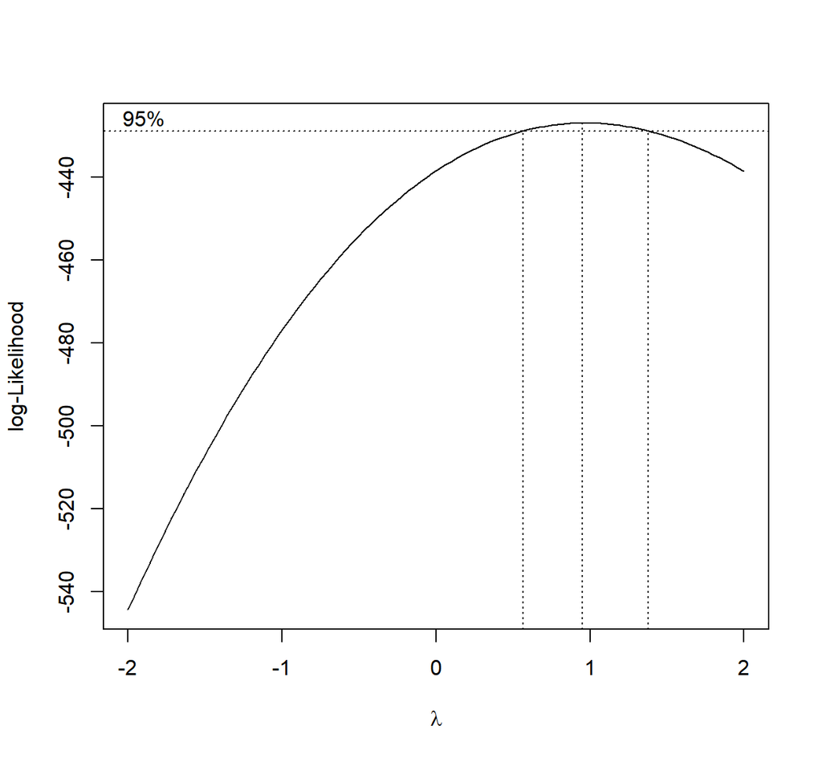

```r
boxcox(meanDockTime ~ condition*block, data=data.group, plotit=T)
```

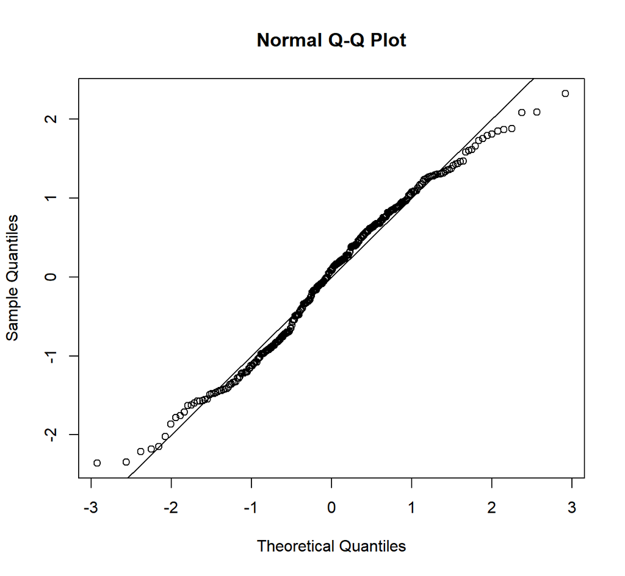

```r
datatr = data.group %>%
    mutate(meanDockTime = meanDockTime^(0.8))

m <- aov(meanDockTime ~ condition*block, data=datatr)
pander(normalCheck(m))
```

Shapiro-Wilk normality test

data: res W = 0.98467, p-value = 0.003599

Shapiro-Wilk normality test: `res`

| Test statistic | P value |
| --- | --- |
| 0.9847 | 0.003599 * * |

Nah, it’s not working - try the ART instead.

### 3.3.3 ANOVAs on ART Data

```r
a = art(meanDockTime ~ methodSwitch*block + Error(participantNo), data=data.group)
anova(a)
```

```
## Analysis of Variance of Aligned Rank Transformed Data
##
## Table Type: Repeated Measures Analysis of Variance Table (Type I)
## Model: Repeated Measures (aov)
## Response: art(meanDockTime)
##
##                      Error Df Df.res   F value  Pr(>F)
## 1 methodSwitch       Withn 11    253 20.678014 < 2e-16 ***
## 2 block              Withn  1    253  0.093198 0.76040
## 3 methodSwitch:block Withn 11    253  0.438249 0.93776
## ---
## Signif. codes:   0 '***' 0.001 '**' 0.01 '*' 0.05 '.' 0.1 ' ' 1
```

### 3.3.4 Post-Hoc Comparisons

```r
b = art.con(a, "methodSwitch") %>% summary() %>% mutate(sig = ifelse(p.value < 0.05, "*", ""))
b
```

```
##  contrast                                          estimate   SE  df t.ratio
##  pen.trackpad,pen - trackpad.trackpad,pen           -98.125 11.8 253  -8.319
##  pen.trackpad,pen - mouse.mouse,pen                 -47.958 11.8 253  -4.066
##  pen.trackpad,pen - pen.mouse,pen                    -5.875 11.8 253  -0.498
##  pen.trackpad,pen - pen.pen,touch                     0.354 11.8 253   0.030
##  pen.trackpad,pen - touch.pen,touch                 -32.042 11.8 253  -2.716
##  pen.trackpad,pen - touch.trackpad,touch            -49.833 11.8 253  -4.225
##  pen.trackpad,pen - trackpad.trackpad,touch         -90.042 11.8 253  -7.634
##  pen.trackpad,pen - mouse.mouse,trackpad            -81.792 11.8 253  -6.934
##  pen.trackpad,pen - trackpad.mouse,trackpad        -104.958 11.8 253  -8.898
##  pen.trackpad,pen - mouse.mouse,touch               -74.042 11.8 253  -6.277
##  pen.trackpad,pen - touch.mouse,touch               -63.188 11.8 253  -5.357
##  trackpad.trackpad,pen - mouse.mouse,pen             50.167 11.8 253   4.253
##  trackpad.trackpad,pen - pen.mouse,pen               92.250 11.8 253   7.821
##  trackpad.trackpad,pen - pen.pen,touch               98.479 11.8 253   8.349
##  trackpad.trackpad,pen - touch.pen,touch             66.083 11.8 253   5.602
##  trackpad.trackpad,pen - touch.trackpad,touch        48.292 11.8 253   4.094
##  trackpad.trackpad,pen - trackpad.trackpad,touch      8.083 11.8 253   0.685
##  trackpad.trackpad,pen - mouse.mouse,trackpad        16.333 11.8 253   1.385
##  trackpad.trackpad,pen - trackpad.mouse,trackpad     -6.833 11.8 253  -0.579
##  trackpad.trackpad,pen - mouse.mouse,touch           24.083 11.8 253   2.042
##  trackpad.trackpad,pen - touch.mouse,touch           34.938 11.8 253   2.962
##  mouse.mouse,pen - pen.mouse,pen                     42.083 11.8 253   3.568
##  mouse.mouse,pen - pen.pen,touch                     48.312 11.8 253   4.096
##  mouse.mouse,pen - touch.pen,touch                   15.917 11.8 253   1.349
##  mouse.mouse,pen - touch.trackpad,touch              -1.875 11.8 253  -0.159
##  mouse.mouse,pen - trackpad.trackpad,touch          -42.083 11.8 253  -3.568
##  mouse.mouse,pen - mouse.mouse,trackpad             -33.833 11.8 253  -2.868
##  mouse.mouse,pen - trackpad.mouse,trackpad          -57.000 11.8 253  -4.832
##  mouse.mouse,pen - mouse.mouse,touch                -26.083 11.8 253  -2.211
##  mouse.mouse,pen - touch.mouse,touch                -15.229 11.8 253  -1.291
##  pen.mouse,pen - pen.pen,touch                        6.229 11.8 253   0.528
##  pen.mouse,pen - touch.pen,touch                    -26.167 11.8 253  -2.218
##  pen.mouse,pen - touch.trackpad,touch               -43.958 11.8 253  -3.727
##  pen.mouse,pen - trackpad.trackpad,touch            -84.167 11.8 253  -7.135
##  pen.mouse,pen - mouse.mouse,trackpad               -75.917 11.8 253  -6.436
##  pen.mouse,pen - trackpad.mouse,trackpad            -99.083 11.8 253  -8.400
##  pen.mouse,pen - mouse.mouse,touch                  -68.167 11.8 253  -5.779
##  pen.mouse,pen - touch.mouse,touch                  -57.312 11.8 253  -4.859
##  pen.pen,touch - touch.pen,touch                    -32.396 11.8 253  -2.746
```

[output cut: 82 more lines]

```
##   0.6570
##   0.9930
##   0.9999
##   0.9827
##   0.9704
##   0.4960
##   0.7172
##   1.0000
##   0.9158
##   0.2736
##   0.0235 *
##   0.9989
##
## Results are averaged over the levels of: block
## P value adjustment: tukey method for comparing a family of 12 estimates
```

```r
docking.postHoc = as.data.frame(b) %>% mutate(sig = ifelse(p.value < 0.05, "*", ""))
```

### 3.3.5 ANOVAs & Post-hoc comparisons on ART Data by Device

#### 3.3.5.1 Mouse

```r
a = art(meanDockTime ~ condition*block + Error(participantNo), data=mouse)
anova(a)
```

```
## Analysis of Variance of Aligned Rank Transformed Data
##
## Table Type: Repeated Measures Analysis of Variance Table (Type I)
## Model: Repeated Measures (aov)
## Response: art(meanDockTime)
##
##                   Error Df Df.res F value   Pr(>F)
## 1 condition       Withn  3     77 4.35853 0.006874 **
## 2 block           Withn  2     77 1.44099 0.243004
## 3 condition:block Withn  2     77 0.26422 0.768497
## ---
## Signif. codes:   0 '***' 0.001 '**' 0.01 '*' 0.05 '.' 0.1 ' ' 1
```

```r
a = art(meanDockTime ~ condition + Error(participantNo), data=mouse)
art.con(a, "condition") %>% summary() %>% mutate(sig = ifelse(p.value < 0.05, "*", ""))
```

```
##  contrast                     estimate   SE df t.ratio p.value sig
##  mouse,pen - mouse,trackpad     -13.00 3.81 81  -3.413  0.0055 *
##  mouse,pen - mouse,touch         -9.48 3.81 81  -2.488  0.0693
##  mouse,pen - mouse,mouse         -3.44 3.81 81  -0.902  0.8036
##  mouse,trackpad - mouse,touch     3.52 3.81 81   0.924  0.7920
##  mouse,trackpad - mouse,mouse     9.56 3.81 81   2.510  0.0658
##  mouse,touch - mouse,mouse        6.04 3.81 81   1.586  0.3923
##
## P value adjustment: tukey method for comparing a family of 4 estimates
```

#### 3.3.5.2 Touch

```r
a = art(meanDockTime ~ condition*block + Error(participantNo), data=touch)
anova(a)
```

```
## Analysis of Variance of Aligned Rank Transformed Data
##
## Table Type: Repeated Measures Analysis of Variance Table (Type I)
## Model: Repeated Measures (aov)
## Response: art(meanDockTime)
##
##                   Error Df Df.res F value   Pr(>F)
## 1 condition       Withn  3     77 5.04045 0.003053 **
## 2 block           Withn  2     77 0.49394 0.612135
## 3 condition:block Withn  2     77 1.30752 0.276427
## ---
## Signif. codes:   0 '***' 0.001 '**' 0.01 '*' 0.05 '.' 0.1 ' ' 1
```

```r
a = art(meanDockTime ~ condition + Error(participantNo), data=touch)
art.con(a, "condition") %>% summary() %>% mutate(sig = ifelse(p.value < 0.05, "*", ""))
```

```
##  contrast                     estimate   SE df t.ratio p.value sig
##  pen,touch - trackpad,touch     -6.333 3.02 81  -2.094  0.1638
##  pen,touch - mouse,touch        -9.375 3.02 81  -3.100  0.0139 *
##  pen,touch - touch,touch        -0.292 3.02 81  -0.096  0.9997
##  trackpad,touch - mouse,touch   -3.042 3.02 81  -1.006  0.7466
##  trackpad,touch - touch,touch    6.042 3.02 81   1.997  0.1975
##  mouse,touch - touch,touch       9.083 3.02 81   3.003  0.0183 *
##
## P value adjustment: tukey method for comparing a family of 4 estimates
```

#### 3.3.5.3 Pen

```r
a = art(meanDockTime ~ condition*block + Error(participantNo), data=pen)
anova(a)
```

```
## Analysis of Variance of Aligned Rank Transformed Data
##
## Table Type: Repeated Measures Analysis of Variance Table (Type I)
## Model: Repeated Measures (aov)
## Response: art(meanDockTime)
##
##                   Error Df Df.res F value   Pr(>F)
## 1 condition       Withn  3     77 2.81827 0.044519 *
## 2 block           Withn  2     77 0.99307 0.375132
## 3 condition:block Withn  2     77 0.43567 0.648415
## ---
## Signif. codes:   0 '***' 0.001 '**' 0.01 '*' 0.05 '.' 0.1 ' ' 1
```

```r
a = art(meanDockTime ~ condition + Error(participantNo), data=pen)
art.con(a, "condition") %>% summary() %>% mutate(sig = ifelse(p.value < 0.05, "*", ""))
```

```
##  contrast                 estimate   SE df t.ratio p.value sig
##  trackpad,pen - mouse,pen   -4.062 2.51 81  -1.620  0.3732
##  trackpad,pen - pen,touch    0.229 2.51 81   0.091  0.9997
##  trackpad,pen - pen,pen      3.167 2.51 81   1.263  0.5890
##  mouse,pen - pen,touch       4.292 2.51 81   1.712  0.3245
##  mouse,pen - pen,pen         7.229 2.51 81   2.883  0.0255 *
##  pen,touch - pen,pen         2.938 2.51 81   1.171  0.6465
##
## P value adjustment: tukey method for comparing a family of 4 estimates
```

#### 3.3.5.4 Trackpad

```r
a = art(meanDockTime ~ condition*block + Error(participantNo), data=trackpad)
anova(a)
```

```
## Analysis of Variance of Aligned Rank Transformed Data
##
## Table Type: Repeated Measures Analysis of Variance Table (Type I)
## Model: Repeated Measures (aov)
## Response: art(meanDockTime)
##
##                   Error Df Df.res F value   Pr(>F)
## 1 condition       Withn  3     77 0.16294 0.920989
## 2 block           Withn  2     77 2.88587 0.061863 .
## 3 condition:block Withn  2     77 0.10410 0.901263
## ---
## Signif. codes:   0 '***' 0.001 '**' 0.01 '*' 0.05 '.' 0.1 ' ' 1
```

```r
a = art(meanDockTime ~ condition + Error(participantNo), data=trackpad)
art.con(a, "condition") %>% summary() %>% mutate(sig = ifelse(p.value < 0.05, "*", ""))
```

```
##  contrast                           estimate   SE df t.ratio p.value sig
##  trackpad,pen - trackpad,touch         1.458 4.86 81   0.300  0.9905
##  trackpad,pen - mouse,trackpad        -1.583 4.86 81  -0.326  0.9880
##  trackpad,pen - trackpad,trackpad      1.292 4.86 81   0.266  0.9934
##  trackpad,touch - mouse,trackpad      -3.042 4.86 81  -0.626  0.9235
##  trackpad,touch - trackpad,trackpad   -0.167 4.86 81  -0.034  1.0000
##  mouse,trackpad - trackpad,trackpad    2.875 4.86 81   0.591  0.9344
##
## P value adjustment: tukey method for comparing a family of 4 estimates
```

# 4 Miss Count

## 4.1 Mode Switching Task

### 4.1.1 Chart

```r
kable(dplyr::select(filter(data.stats, task == 'task'), task, methodSwitch, mMC, sdMC))
```

| condition | task | methodSwitch | mMC | sdMC |
| --- | --- | --- | --- | --- |
| trackpad,pen | task | pen.trackpad,pen | 0.0781250 | 0.3221990 |
| trackpad,pen | task | trackpad.trackpad,pen | 0.2328042 | 0.5445895 |
| mouse,pen | task | mouse.mouse,pen | 0.1406250 | 0.4293129 |
| mouse,pen | task | pen.mouse,pen | 0.0833333 | 0.3593673 |
| pen,touch | task | pen.pen,touch | 0.1875000 | 0.4533182 |
| pen,touch | task | touch.pen,touch | 0.5240642 | 1.4894643 |
| trackpad,touch | task | touch.trackpad,touch | 0.2500000 | 0.7860032 |
| trackpad,touch | task | trackpad.trackpad,touch | 0.1727749 | 0.5491545 |
| mouse,trackpad | task | mouse.mouse,trackpad | 0.1570681 | 0.4185687 |
| mouse,trackpad | task | trackpad.mouse,trackpad | 0.1623037 | 0.4470287 |
| mouse,touch | task | mouse.mouse,touch | 0.1518325 | 0.4507121 |
| mouse,touch | task | touch.mouse,touch | 0.1875000 | 0.6758745 |

### 4.1.2 Graph

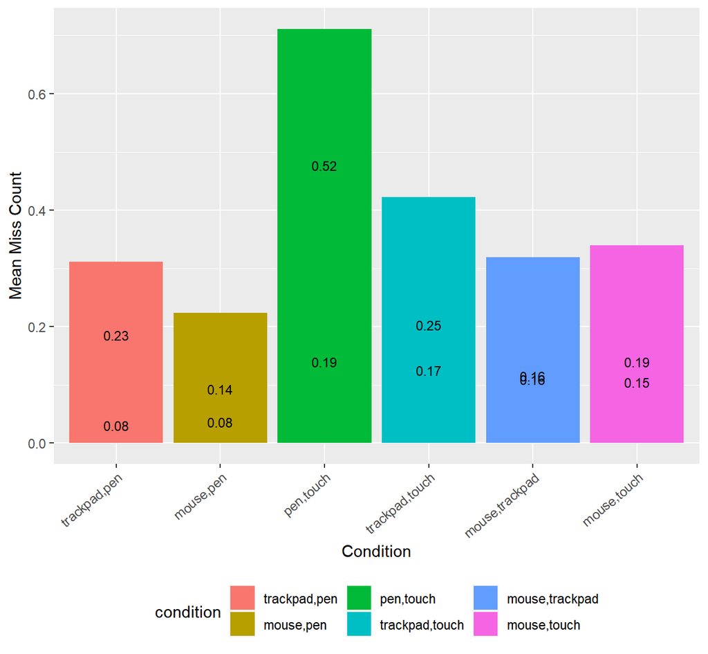

```r
ggplot(data=filter(data.stats, task == 'task'), aes(x=condition, y=mMC, fill=condition)) +
  geom_bar(stat="identity") +
  geom_text(aes(label=round(mMC,digits=2)), size = 3, position = position_dodge(0.7), vjust = 3.2) +
  scale_x_discrete(name="Condition") +
  scale_y_continuous(name="Mean Miss Count") +
  theme(axis.text.x = element_text(angle = 40, vjust = 1, hjust=1),
        legend.position = 'bottom')
```

```r
# ggplot(data=filter(data.stats.block, task == 'task'), aes(x=interaction(block, condition), y=mMC, fill=condition)) +
#   geom_bar(stat="identity") +
#   geom_text(aes(label=round(mMC,digits=2)), size = 3, position = position_dodge(0.7), vjust = 3.2) +
#   scale_x_discrete(name="Condition") +
#   scale_y_continuous(name="Mean Miss Count") +
#   theme(axis.text.x = element_text(angle = 40, vjust = 1, hjust=1),
#         legend.position = 'bottom')
```

### 4.1.3 Percentages

```r
mean(data$missCount)
```

```
## [1] 0.194578
```

```r
sd(data$missCount)
```

```
## [1] 0.6584786
```

```r
sum(data$wrongModeCount) / (sum(data$posMissCount) + sum(data$wrongModeCount)) * 100
```

```
## [1] 6.360078
```

```r
sum(data$posMissCount) / (sum(data$posMissCount) + sum(data$wrongModeCount)) * 100
```

```
## [1] 93.63992
```

## 4.2 Baseline Task

### 4.2.1 Chart

```r
kable(dplyr::select(filter(data.stats, task == 'baseline'), task, condition, mMC, sdMC))
```

| methodSwitch | task | condition | mMC | sdMC |
| --- | --- | --- | --- | --- |
| mouse.mouse,mouse | baseline | mouse,mouse | 0.0861160 | 0.3324586 |
| pen.pen,pen | baseline | pen,pen | 0.0877193 | 0.3069609 |
| touch.touch,touch | baseline | touch,touch | 0.4048866 | 1.0758525 |
| trackpad.trackpad,trackpad | baseline | trackpad,trackpad | 0.2035088 | 0.5599287 |

### 4.2.2 Graph

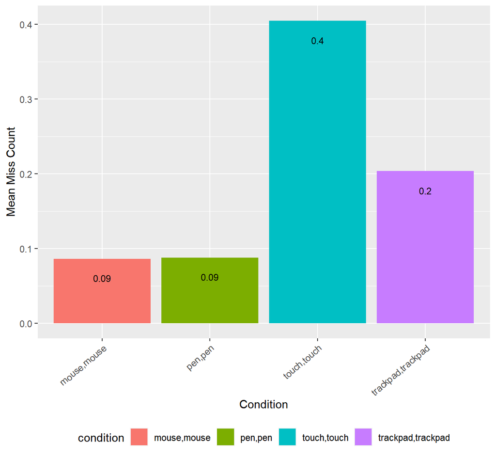

```r
ggplot(data=filter(data.stats, task == 'baseline'), aes(x=condition, y=mMC, fill=condition)) +
  geom_bar(stat="identity") +
  geom_text(aes(label=round(mMC,digits=2)), size = 3, position = position_dodge(0.7), vjust = 3.2) +
  scale_x_discrete(name="Condition") +
  scale_y_continuous(name="Mean Miss Count") +
  theme(axis.text.x = element_text(angle = 40, vjust = 1, hjust=1),
        legend.position = 'bottom')
```

## 4.3 Effect of Mode Switching Devices

### 4.3.1 Normality Check

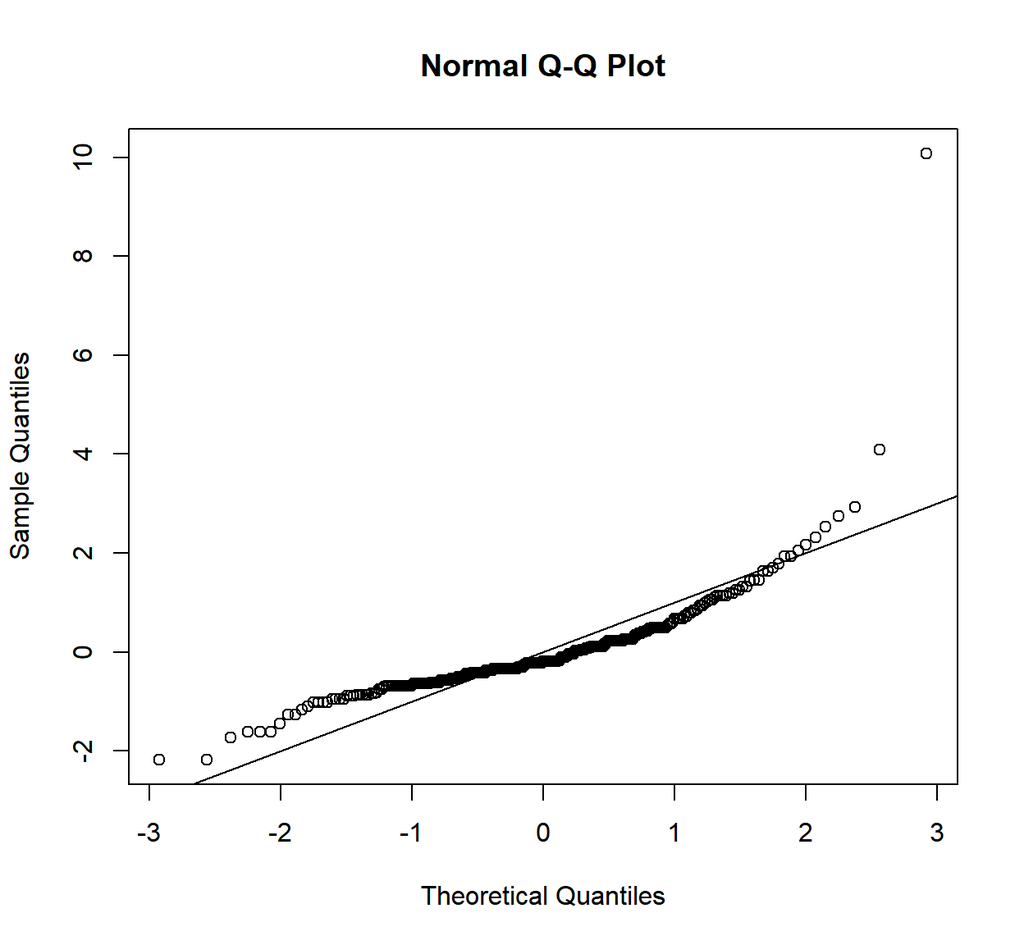

```r
m <- aov(meanMisses ~ methodSwitch*block, data=data.group)
pander(normalCheck(m))
```

Shapiro-Wilk normality test

data: res W = 0.74064, p-value < 2.2e-16

Shapiro-Wilk normality test: `res`

| Test statistic | P value |
| --- | --- |
| 0.7406 | 6.139e-21 * * * |

Not normally distributed, need to do transform?

### 4.3.2 Box-Cox Transformation

```r
#boxcox(meanMisses ~ task*condition*block, data=data.long, plotit=T)
```

Not all values are positive - cannot do Box-Cox transform

```r
# datatr = data.long %>%
#     mutate(meanDockTime = meanDockTime^(-0.2))
#
# m <- aov(meanDockTime ~ task*condition, data=datatr)
# pander(normalCheck(m))
```

### 4.3.3 ANOVAs on ART Data

```r
a = art(meanMisses ~ methodSwitch*block + Error(participantNo), data=data.group)
anova(a)
```

```
## Analysis of Variance of Aligned Rank Transformed Data
##
## Table Type: Repeated Measures Analysis of Variance Table (Type I)
## Model: Repeated Measures (aov)
## Response: art(meanMisses)
##
##                      Error Df Df.res F value    Pr(>F)
## 1 methodSwitch       Withn 11    253 2.73587 0.0023242 **
## 2 block              Withn  1    253 1.72705 0.1899777
## 3 methodSwitch:block Withn 11    253 0.83689 0.6032568
## ---
## Signif. codes:   0 '***' 0.001 '**' 0.01 '*' 0.05 '.' 0.1 ' ' 1
```

### 4.3.4 Post-Hoc Comparisons

```r
b = art.con(a, "methodSwitch") %>% summary() %>% mutate(sig = ifelse(p.value < 0.05, "*", ""))
b
```

```
##  contrast                                          estimate   SE  df t.ratio
##  pen.trackpad,pen - trackpad.trackpad,pen           -69.271 21.9 253  -3.156
##  pen.trackpad,pen - mouse.mouse,pen                 -36.125 21.9 253  -1.646
##  pen.trackpad,pen - pen.mouse,pen                   -11.458 21.9 253  -0.522
##  pen.trackpad,pen - pen.pen,touch                   -51.208 21.9 253  -2.333
##  pen.trackpad,pen - touch.pen,touch                 -98.292 21.9 253  -4.478
##  pen.trackpad,pen - touch.trackpad,touch            -61.958 21.9 253  -2.823
##  pen.trackpad,pen - trackpad.trackpad,touch         -36.667 21.9 253  -1.671
##  pen.trackpad,pen - mouse.mouse,trackpad            -36.875 21.9 253  -1.680
##  pen.trackpad,pen - trackpad.mouse,trackpad         -50.396 21.9 253  -2.296
##  pen.trackpad,pen - mouse.mouse,touch               -34.833 21.9 253  -1.587
##  pen.trackpad,pen - touch.mouse,touch               -45.917 21.9 253  -2.092
##  trackpad.trackpad,pen - mouse.mouse,pen             33.146 21.9 253   1.510
##  trackpad.trackpad,pen - pen.mouse,pen               57.812 21.9 253   2.634
##  trackpad.trackpad,pen - pen.pen,touch               18.062 21.9 253   0.823
##  trackpad.trackpad,pen - touch.pen,touch            -29.021 21.9 253  -1.322
##  trackpad.trackpad,pen - touch.trackpad,touch         7.312 21.9 253   0.333
##  trackpad.trackpad,pen - trackpad.trackpad,touch     32.604 21.9 253   1.485
##  trackpad.trackpad,pen - mouse.mouse,trackpad        32.396 21.9 253   1.476
##  trackpad.trackpad,pen - trackpad.mouse,trackpad     18.875 21.9 253   0.860
##  trackpad.trackpad,pen - mouse.mouse,touch           34.438 21.9 253   1.569
##  trackpad.trackpad,pen - touch.mouse,touch           23.354 21.9 253   1.064
##  mouse.mouse,pen - pen.mouse,pen                     24.667 21.9 253   1.124
##  mouse.mouse,pen - pen.pen,touch                    -15.083 21.9 253  -0.687
##  mouse.mouse,pen - touch.pen,touch                  -62.167 21.9 253  -2.832
##  mouse.mouse,pen - touch.trackpad,touch             -25.833 21.9 253  -1.177
##  mouse.mouse,pen - trackpad.trackpad,touch           -0.542 21.9 253  -0.025
##  mouse.mouse,pen - mouse.mouse,trackpad              -0.750 21.9 253  -0.034
##  mouse.mouse,pen - trackpad.mouse,trackpad          -14.271 21.9 253  -0.650
##  mouse.mouse,pen - mouse.mouse,touch                  1.292 21.9 253   0.059
##  mouse.mouse,pen - touch.mouse,touch                 -9.792 21.9 253  -0.446
##  pen.mouse,pen - pen.pen,touch                      -39.750 21.9 253  -1.811
##  pen.mouse,pen - touch.pen,touch                    -86.833 21.9 253  -3.956
##  pen.mouse,pen - touch.trackpad,touch               -50.500 21.9 253  -2.301
##  pen.mouse,pen - trackpad.trackpad,touch            -25.208 21.9 253  -1.149
##  pen.mouse,pen - mouse.mouse,trackpad               -25.417 21.9 253  -1.158
##  pen.mouse,pen - trackpad.mouse,trackpad            -38.938 21.9 253  -1.774
##  pen.mouse,pen - mouse.mouse,touch                  -23.375 21.9 253  -1.065
##  pen.mouse,pen - touch.mouse,touch                  -34.458 21.9 253  -1.570
##  pen.pen,touch - touch.pen,touch                    -47.083 21.9 253  -2.145
```

[output cut: 82 more lines]

```
##   0.9856
##   0.9999
##   1.0000
##   1.0000
##   1.0000
##   1.0000
##   1.0000
##   1.0000
##   1.0000
##   0.9999
##   1.0000
##   1.0000
##
## Results are averaged over the levels of: block
## P value adjustment: tukey method for comparing a family of 12 estimates
```

```r
mc.postHoc = as.data.frame(b) %>% mutate(sig = ifelse(p.value < 0.05, "*", ""))
art.con(a, "block") %>% summary() %>% mutate(sig = ifelse(p.value < 0.05, "*", ""))
```

```
##  contrast estimate   SE  df t.ratio p.value sig
##  3 - 4        12.1 9.18 253   1.314  0.1900
##
## Results are averaged over the levels of: methodSwitch
```

### 4.3.5 ANOVAs & Post-hoc comparisons on ART Data by Device

#### 4.3.5.1 Mouse

```r
a = art(meanMisses ~ condition*block + Error(participantNo), data=mouse)
anova(a)
```

```
## Analysis of Variance of Aligned Rank Transformed Data
##
## Table Type: Repeated Measures Analysis of Variance Table (Type I)
## Model: Repeated Measures (aov)
## Response: art(meanMisses)
##
##                   Error Df Df.res F value  Pr(>F)
## 1 condition       Withn  3     77 0.37769 0.76934
## 2 block           Withn  2     77 0.53360 0.58864
## 3 condition:block Withn  2     77 1.02862 0.36236
## ---
## Signif. codes:   0 '***' 0.001 '**' 0.01 '*' 0.05 '.' 0.1 ' ' 1
```

```r
a = art(meanMisses ~ condition + Error(participantNo), data=mouse)
art.con(a, "condition") %>% summary() %>% mutate(sig = ifelse(p.value < 0.05, "*", ""))
```

```
##  contrast                     estimate   SE df t.ratio p.value sig
##  mouse,pen - mouse,trackpad     -2.333 6.94 81  -0.336  0.9868
##  mouse,pen - mouse,touch        -1.417 6.94 81  -0.204  0.9970
##  mouse,pen - mouse,mouse         3.583 6.94 81   0.517  0.9549
##  mouse,trackpad - mouse,touch    0.917 6.94 81   0.132  0.9992
##  mouse,trackpad - mouse,mouse    5.917 6.94 81   0.853  0.8289
##  mouse,touch - mouse,mouse       5.000 6.94 81   0.721  0.8886
##
## P value adjustment: tukey method for comparing a family of 4 estimates
```

#### 4.3.5.2 Touch

```r
a = art(meanMisses ~ condition*block + Error(participantNo), data=touch)
anova(a)
```

```
## Analysis of Variance of Aligned Rank Transformed Data
##
## Table Type: Repeated Measures Analysis of Variance Table (Type I)
## Model: Repeated Measures (aov)
## Response: art(meanMisses)
##
##                   Error Df Df.res F value    Pr(>F)
## 1 condition       Withn  3     77 4.58971 0.0052139 **
## 2 block           Withn  2     77 2.82580 0.0654212  .
## 3 condition:block Withn  2     77 0.22069 0.8024720
## ---
## Signif. codes:   0 '***' 0.001 '**' 0.01 '*' 0.05 '.' 0.1 ' ' 1
```

```r
a = art(meanMisses ~ condition + Error(participantNo), data=touch)
art.con(a, "condition") %>% summary() %>% mutate(sig = ifelse(p.value < 0.05, "*", ""))
```

```
##  contrast                     estimate   SE df t.ratio p.value sig
##  pen,touch - trackpad,touch      11.58 7.16 81   1.618  0.3746
##  pen,touch - mouse,touch         19.12 7.16 81   2.671  0.0444 *
##  pen,touch - touch,touch         -6.21 7.16 81  -0.867  0.8218
##  trackpad,touch - mouse,touch     7.54 7.16 81   1.053  0.7187
##  trackpad,touch - touch,touch   -17.79 7.16 81  -2.485  0.0700
##  mouse,touch - touch,touch      -25.33 7.16 81  -3.538  0.0037 *
##
## P value adjustment: tukey method for comparing a family of 4 estimates
```

#### 4.3.5.3 Pen

```r
a = art(meanMisses ~ condition*block + Error(participantNo), data=pen)
anova(a)
```

```
## Analysis of Variance of Aligned Rank Transformed Data
##
## Table Type: Repeated Measures Analysis of Variance Table (Type I)
## Model: Repeated Measures (aov)
## Response: art(meanMisses)
##
##                   Error Df Df.res F value   Pr(>F)
## 1 condition       Withn  3     77 2.86772 0.041907 *
## 2 block           Withn  2     77 0.34564 0.708862
## 3 condition:block Withn  2     77 0.83344 0.438434
## ---
## Signif. codes:   0 '***' 0.001 '**' 0.01 '*' 0.05 '.' 0.1 ' ' 1
```

```r
a = art(meanMisses ~ condition + Error(participantNo), data=pen)
art.con(a, "condition") %>% summary() %>% mutate(sig = ifelse(p.value < 0.05, "*", ""))
```

```
##  contrast                 estimate   SE df t.ratio p.value sig
##  trackpad,pen - mouse,pen    -3.94 6.63 81  -0.594  0.9336
##  trackpad,pen - pen,touch   -19.29 6.63 81  -2.911  0.0236 *
##  trackpad,pen - pen,pen     -10.77 6.63 81  -1.625  0.3703
##  mouse,pen - pen,touch      -15.35 6.63 81  -2.317  0.1026
##  mouse,pen - pen,pen         -6.83 6.63 81  -1.031  0.7317
##  pen,touch - pen,pen          8.52 6.63 81   1.286  0.5746
##
## P value adjustment: tukey method for comparing a family of 4 estimates
```

#### 4.3.5.4 Trackpad

```r
a = art(meanMisses ~ condition*block + Error(participantNo), data=trackpad)
anova(a)
```

```
## Analysis of Variance of Aligned Rank Transformed Data
##
## Table Type: Repeated Measures Analysis of Variance Table (Type I)
## Model: Repeated Measures (aov)
## Response: art(meanMisses)
##
##                   Error Df Df.res F value  Pr(>F)
## 1 condition       Withn  3     77 1.61848 0.19196
## 2 block           Withn  2     77 0.52943 0.59107
## 3 condition:block Withn  2     77 0.61228 0.54473
## ---
## Signif. codes:   0 '***' 0.001 '**' 0.01 '*' 0.05 '.' 0.1 ' ' 1
```

```r
a = art(meanMisses ~ condition + Error(participantNo), data=trackpad)
art.con(a, "condition") %>% summary() %>% mutate(sig = ifelse(p.value < 0.05, "*", ""))
```

```
##  contrast                           estimate   SE df t.ratio p.value sig
##  trackpad,pen - trackpad,touch        11.104 6.57 81   1.691  0.3353
##  trackpad,pen - mouse,trackpad         7.667 6.57 81   1.167  0.6491
##  trackpad,pen - trackpad,trackpad      0.562 6.57 81   0.086  0.9998
##  trackpad,touch - mouse,trackpad      -3.438 6.57 81  -0.523  0.9532
##  trackpad,touch - trackpad,trackpad  -10.542 6.57 81  -1.605  0.3816
##  mouse,trackpad - trackpad,trackpad   -7.104 6.57 81  -1.082  0.7017
##
## P value adjustment: tukey method for comparing a family of 4 estimates
```

# 5 Mode Switching Time

## 5.1 Mode Switching Task

### 5.1.1 Chart

```r
kable(dplyr::select(filter(data.ms.stats.block, task == 'task'), task, condition, mMTB, sdMTB))
```

| task | condition | mMTB | sdMTB |
| --- | --- | --- | --- |
| task | mouse,pen | 679.5280 | 693.2578 |
| task | mouse,pen | 643.3916 | 647.6734 |
| task | mouse,touch | 719.1879 | 664.3943 |
| task | mouse,touch | 772.0848 | 733.3435 |
| task | mouse,trackpad | 680.5685 | 774.3577 |
| task | mouse,trackpad | 704.0889 | 747.8599 |
| task | pen,touch | 460.4985 | 745.7366 |
| task | pen,touch | 499.3080 | 852.8042 |
| task | trackpad,pen | 738.5432 | 790.2913 |
| task | trackpad,pen | 511.9509 | 781.4263 |
| task | trackpad,touch | 431.9000 | 784.4164 |
| task | trackpad,touch | 432.4049 | 823.1311 |

### 5.1.2 Graph

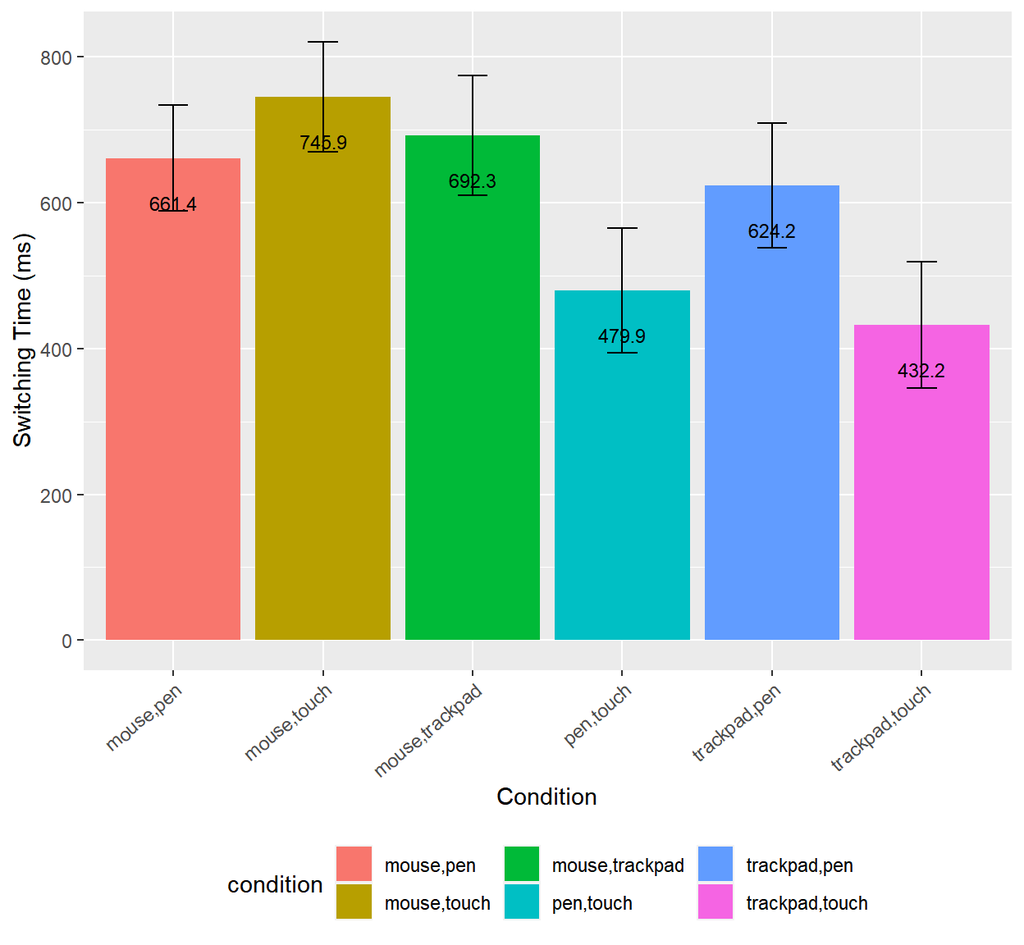

```r
ggplot(data=filter(data.ms.stats, task == 'task'), aes(x=condition, y=mMTB, fill=condition)) +
  geom_bar(stat="identity") +
  geom_errorbar(aes(ymin = clMTB, ymax = cuMTB), width = 0.2, size = .5, position = position_dodge(.7)) +
  geom_text(aes(label=round(mMTB,digits=1)), size = 3, position = position_dodge(0.7), vjust = 3.5) +
  scale_x_discrete(name="Condition") +
  scale_y_continuous(name="Switching Time (ms)") +
  theme(axis.text.x = element_text(angle = 40, vjust = 1, hjust=1),
        legend.position = 'bottom')
```

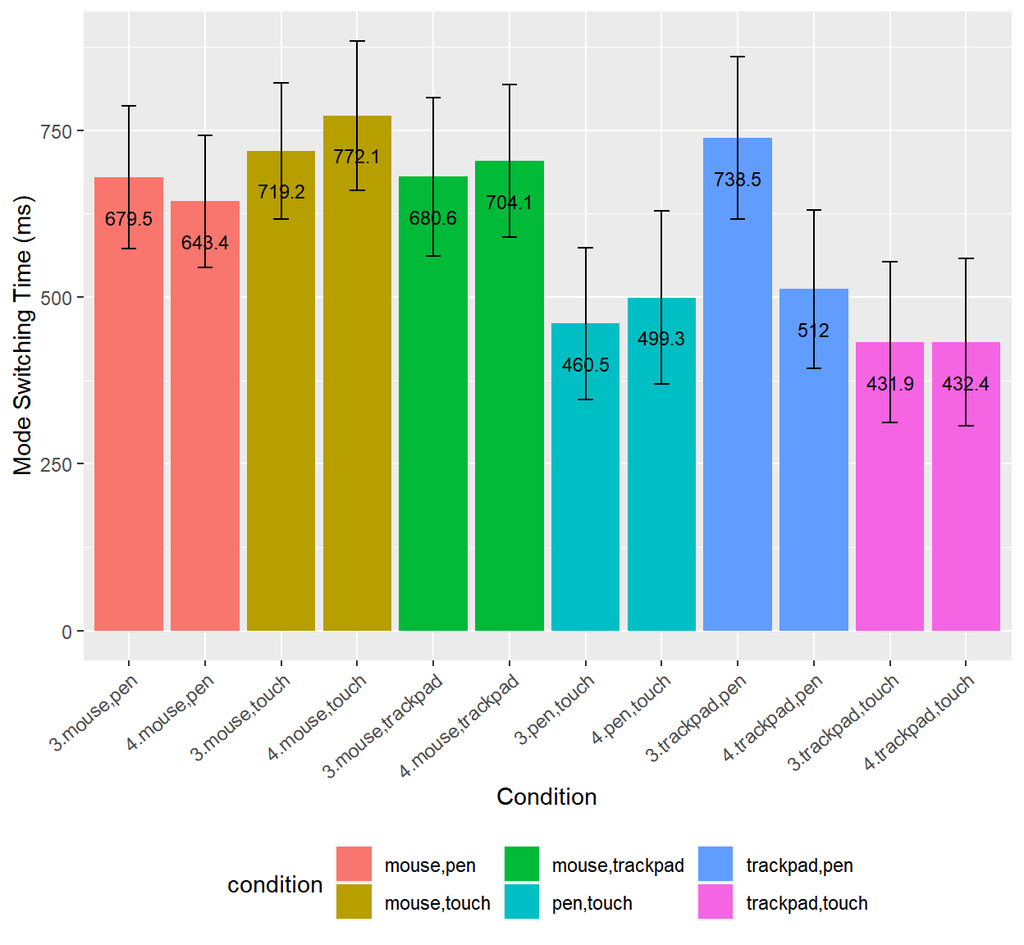

```r
ggplot(data=filter(data.ms.stats.block, task == 'task'), aes(x=interaction(block, condition), y=mMTB, fill=condition)) +
  geom_bar(stat="identity") +
  geom_errorbar(aes(ymin = clMTB, ymax = cuMTB), width = 0.2, size = .5, position = position_dodge(.7)) +
  geom_text(aes(label=round(mMTB,digits=1)), size = 3, position = position_dodge(0.7), vjust = 3.2) +
  scale_x_discrete(name="Condition") +
  scale_y_continuous(name="Mode Switching Time (ms)") +
  theme(axis.text.x = element_text(angle = 40, vjust = 1, hjust=1),
        legend.position = 'bottom')
```

## 5.2 Effect of Task & Mode Switching Devices

### 5.2.1 Normality Check

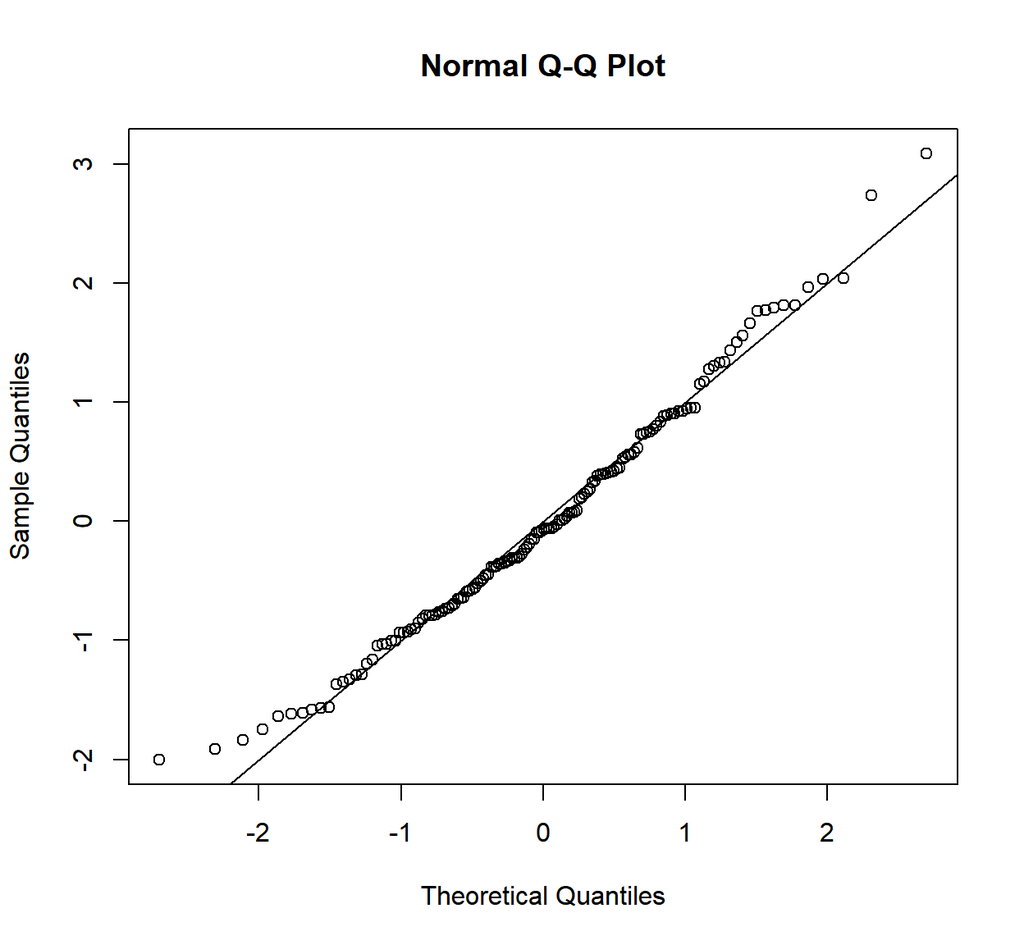

```r
m <- aov(meanMSTimeB ~ condition*block, data=filter(data.ms.group, task == 'task'))
pander(normalCheck(m))
```

Shapiro-Wilk normality test

data: res W = 0.98459, p-value = 0.107

Shapiro-Wilk normality test: `res`

| Test statistic | P value |
| --- | --- |
| 0.9846 | 0.107 |

Cannot run Box-Cox with negative values.

### 5.2.2 ANOVAs on ART Data

```r
a = art(meanMSTimeB ~ condition*block + Error(participantNo), data=data.ms.group)
anova(a)
```

```
## Analysis of Variance of Aligned Rank Transformed Data
##
## Table Type: Repeated Measures Analysis of Variance Table (Type I)
## Model: Repeated Measures (aov)
## Response: art(meanMSTimeB)
##
##                   Error Df Df.res F value    Pr(>F)
## 1 condition       Withn  5    121 3.34139 0.0073136 **
## 2 block           Withn  1    121 0.41392 0.5212023
## 3 condition:block Withn  5    121 0.63254 0.6752528
## ---
## Signif. codes:   0 '***' 0.001 '**' 0.01 '*' 0.05 '.' 0.1 ' ' 1
```

## 5.3 Mode Switching Task by Direction

### 5.3.1 Chart

```r
kable(dplyr::select(filter(data.ms.stats.direction, task == 'task'), task, condition, direction, mMTB, sdMTB))
```

| task | condition | direction | mMTB | sdMTB |
| --- | --- | --- | --- | --- |
| task | mouse,pen | Mouse to Pen | 614.5787 | 655.0954 |
| task | mouse,pen | Pen to Mouse | 723.7306 | 686.7316 |
| task | mouse,touch | Mouse to Touch | 629.4738 | 714.6565 |
| task | mouse,touch | Touch to Mouse | 902.4419 | 648.6698 |
| task | mouse,trackpad | Mouse to Trackpad | 584.2932 | 823.6072 |
| task | mouse,trackpad | Trackpad to Mouse | 833.3750 | 644.2968 |
| task | pen,touch | Pen to Touch | 427.7812 | 907.7913 |
| task | pen,touch | Touch to Pen | 549.3993 | 624.8731 |
| task | trackpad,pen | Pen to Trackpad | 465.2835 | 834.0376 |
| task | trackpad,pen | Trackpad to Pen | 742.3933 | 741.0522 |
| task | trackpad,touch | Touch to Trackpad | 602.5293 | 685.4768 |
| task | trackpad,touch | Trackpad to Touch | 306.3796 | 859.8831 |

```r
kable(dplyr::select(filter(data.ms.stats.direction.block, task == 'task'), task, condition, direction, block, mMTB, sdMTB))
```

| cycleType | task | condition | direction | block | mMTB | sdMTB |
| --- | --- | --- | --- | --- | --- | --- |
| A | task | mouse,pen | Mouse to Pen | 3 | 613.1476 | 680.5703 |
| A | task | mouse,pen | Mouse to Pen | 4 | 615.9947 | 632.4928 |
| B | task | mouse,pen | Pen to Mouse | 3 | 767.4120 | 704.8963 |
| B | task | mouse,pen | Pen to Mouse | 4 | 680.0493 | 670.2152 |
| A | task | mouse,touch | Mouse to Touch | 3 | 577.4368 | 684.1893 |
| A | task | mouse,touch | Mouse to Touch | 4 | 680.9688 | 743.5677 |
| B | task | mouse,touch | Touch to Mouse | 3 | 911.5643 | 588.4217 |
| B | task | mouse,touch | Touch to Mouse | 4 | 893.5729 | 706.3780 |
| A | task | mouse,trackpad | Mouse to Trackpad | 3 | 549.6529 | 825.0886 |
| A | task | mouse,trackpad | Mouse to Trackpad | 4 | 618.9335 | 825.0785 |
| B | task | mouse,trackpad | Trackpad to Mouse | 3 | 851.4861 | 670.4300 |
| B | task | mouse,trackpad | Trackpad to Mouse | 4 | 815.2639 | 621.2422 |
| A | task | pen,touch | Pen to Touch | 3 | 405.5208 | 832.1863 |
| A | task | pen,touch | Pen to Touch | 4 | 450.0417 | 981.4830 |
| B | task | pen,touch | Touch to Pen | 3 | 533.8021 | 609.8346 |
| B | task | pen,touch | Touch to Pen | 4 | 564.9965 | 643.4599 |
| B | task | trackpad,pen | Pen to Trackpad | 3 | 616.3357 | 845.6631 |
| B | task | trackpad,pen | Pen to Trackpad | 4 | 318.4271 | 801.2945 |
| A | task | trackpad,pen | Trackpad to Pen | 3 | 828.5908 | 738.5083 |
| A | task | trackpad,pen | Trackpad to Pen | 4 | 657.0938 | 737.4827 |
| B | task | trackpad,touch | Touch to Trackpad | 3 | 612.9429 | 622.8831 |
| B | task | trackpad,touch | Touch to Trackpad | 4 | 592.2623 | 746.3918 |
| A | task | trackpad,touch | Trackpad to Touch | 3 | 298.5000 | 863.9033 |
| A | task | trackpad,touch | Trackpad to Touch | 4 | 314.1771 | 860.3497 |

### 5.3.2 Graph

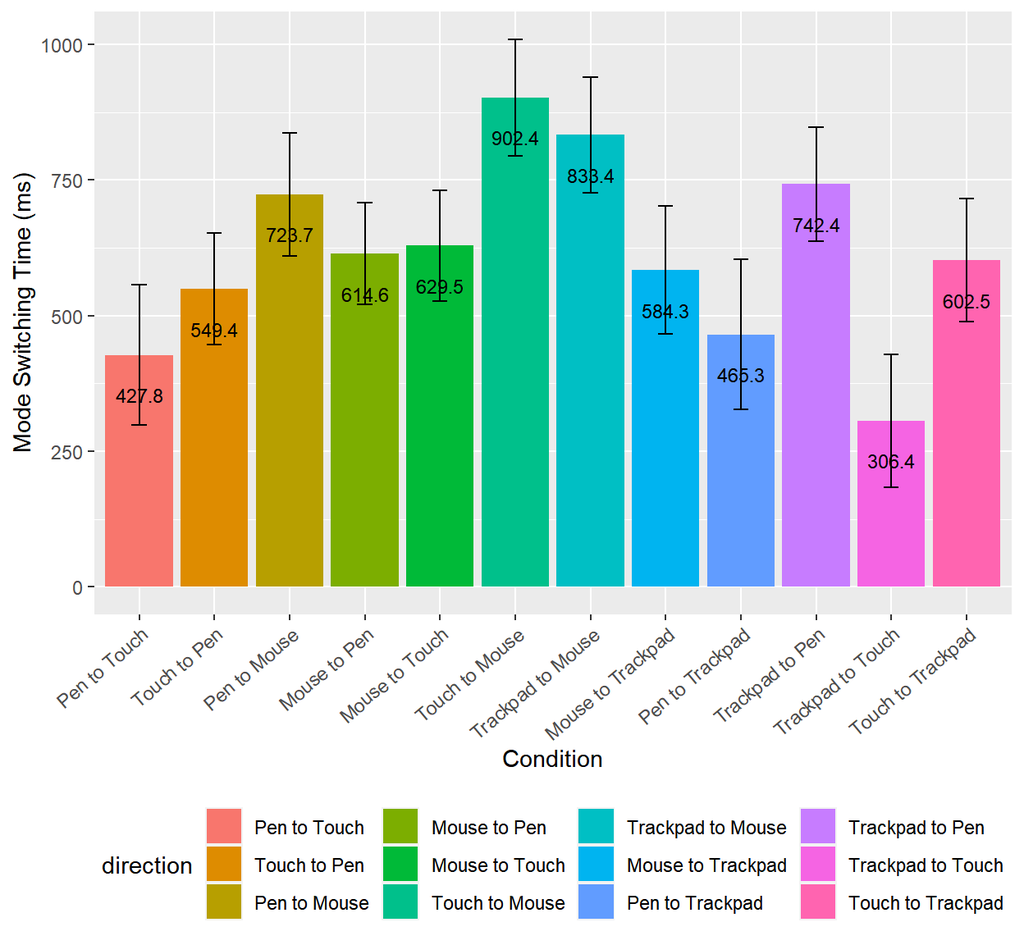

```r
ggplot(data=filter(data.ms.stats.direction, task == 'task'), aes(x=direction, y=mMTB, fill=direction)) +
  geom_bar(stat="identity") +
  geom_errorbar(aes(ymin = clMTB, ymax = cuMTB), width = 0.2, size = .5, position = position_dodge(.7)) +
  geom_text(aes(label=round(mMTB,digits=1)), size = 3, position = position_dodge(0.7), vjust = 3.2) +
  scale_x_discrete(name="Condition") +
  scale_y_continuous(name="Mode Switching Time (ms)") +
  theme(axis.text.x = element_text(angle = 40, vjust = 1, hjust=1),
        legend.position = 'bottom')
```

```r
# ggplot(data=filter(data.ms.stats.direction.block, task == 'task'), aes(x=interaction(block, direction), y=mMTB, fill=direction)) +
#   geom_bar(stat="identity") +
#   geom_errorbar(aes(ymin = clMTB, ymax = cuMTB), width = 0.2, size = .5, position = position_dodge(.7)) +
#   geom_text(aes(label=round(mMTB,digits=1)), size = 3, position = position_dodge(0.7), vjust = 3.2) +
#   scale_x_discrete(name="Condition") +
#   scale_y_continuous(name="Mode Switching Time (ms)") +
#   theme(axis.text.x = element_text(angle = 40, vjust = 1, hjust=1),
#         legend.position = 'bottom')
```

## 5.4 Effect of Task & Mode Switching Devices

### 5.4.1 Normality Check

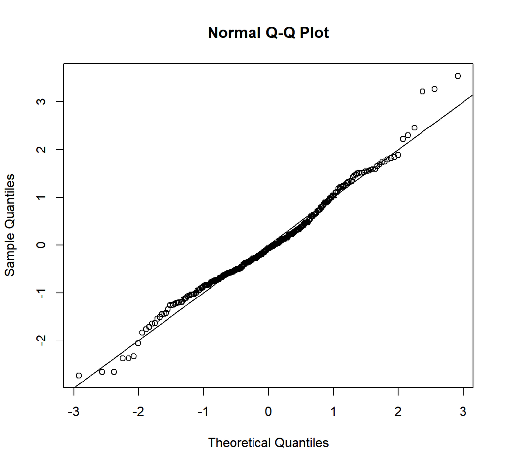

```r
m <- aov(meanMSTimeB ~ block*direction, data=filter(data.ms.dir, task == 'task'))
pander(normalCheck(m))
```

Shapiro-Wilk normality test

data: res W = 0.98458, p-value = 0.003446

Shapiro-Wilk normality test: `res`

| Test statistic | P value |
| --- | --- |
| 0.9846 | 0.003446 * * |

Can’t run Box-Cox due to negative mode switching times.

### 5.4.2 ANOVAs on ART Data

```r
a = art(meanMSTimeB ~ direction*block + Error(participantNo), data=filter(data.ms.dir, task == 'task'))
anova(a)
```

```
## Analysis of Variance of Aligned Rank Transformed Data
##
## Table Type: Repeated Measures Analysis of Variance Table (Type I)
## Model: Repeated Measures (aov)
## Response: art(meanMSTimeB)
##
##                   Error Df Df.res F value     Pr(>F)
## 1 direction       Withn 11    253 4.40721 4.6071e-06 ***
## 2 block           Withn  1    253 1.43835    0.23153
## 3 direction:block Withn 11    253 0.38242    0.96217
## ---
## Signif. codes:   0 '***' 0.001 '**' 0.01 '*' 0.05 '.' 0.1 ' ' 1
```

### 5.4.3 Post-Hoc Comparisons

```r
b = art.con(a, "direction") %>% summary() %>% mutate(sig = ifelse(p.value < 0.05, "*", ""))
b
```

```
##  contrast                              estimate   SE  df t.ratio p.value sig
##  Mouse to Pen - Mouse to Touch            -2.54 19.4 253  -0.131  1.0000
##  Mouse to Pen - Mouse to Trackpad         18.88 19.4 253   0.972  0.9981
##  Mouse to Pen - Pen to Mouse             -18.46 19.4 253  -0.950  0.9985
##  Mouse to Pen - Pen to Touch              35.08 19.4 253   1.806  0.8133
##  Mouse to Pen - Pen to Trackpad           20.42 19.4 253   1.051  0.9963
##  Mouse to Pen - Touch to Mouse           -52.17 19.4 253  -2.686  0.2396
##  Mouse to Pen - Touch to Pen              10.75 19.4 253   0.553  1.0000
##  Mouse to Pen - Touch to Trackpad          8.21 19.4 253   0.423  1.0000
##  Mouse to Pen - Trackpad to Mouse        -41.50 19.4 253  -2.137  0.5971
##  Mouse to Pen - Trackpad to Pen          -24.38 19.4 253  -1.255  0.9837
##  Mouse to Pen - Trackpad to Touch         39.71 19.4 253   2.044  0.6626
##  Mouse to Touch - Mouse to Trackpad       21.42 19.4 253   1.103  0.9944
##  Mouse to Touch - Pen to Mouse           -15.92 19.4 253  -0.819  0.9996
##  Mouse to Touch - Pen to Touch            37.62 19.4 253   1.937  0.7348
##  Mouse to Touch - Pen to Trackpad         22.96 19.4 253   1.182  0.9899
##  Mouse to Touch - Touch to Mouse         -49.62 19.4 253  -2.555  0.3115
##  Mouse to Touch - Touch to Pen            13.29 19.4 253   0.684  0.9999
##  Mouse to Touch - Touch to Trackpad       10.75 19.4 253   0.553  1.0000
##  Mouse to Touch - Trackpad to Mouse      -38.96 19.4 253  -2.006  0.6892
##  Mouse to Touch - Trackpad to Pen        -21.83 19.4 253  -1.124  0.9934
##  Mouse to Touch - Trackpad to Touch       42.25 19.4 253   2.175  0.5692
##  Mouse to Trackpad - Pen to Mouse        -37.33 19.4 253  -1.922  0.7444
##  Mouse to Trackpad - Pen to Touch         16.21 19.4 253   0.834  0.9995
##  Mouse to Trackpad - Pen to Trackpad       1.54 19.4 253   0.079  1.0000
##  Mouse to Trackpad - Touch to Mouse      -71.04 19.4 253  -3.657  0.0159 *
##  Mouse to Trackpad - Touch to Pen         -8.12 19.4 253  -0.418  1.0000
##  Mouse to Trackpad - Touch to Trackpad   -10.67 19.4 253  -0.549  1.0000
##  Mouse to Trackpad - Trackpad to Mouse   -60.38 19.4 253  -3.108  0.0861
##  Mouse to Trackpad - Trackpad to Pen     -43.25 19.4 253  -2.227  0.5320
##  Mouse to Trackpad - Trackpad to Touch    20.83 19.4 253   1.073  0.9956
##  Pen to Mouse - Pen to Touch              53.54 19.4 253   2.756  0.2056
##  Pen to Mouse - Pen to Trackpad           38.88 19.4 253   2.001  0.6921
##  Pen to Mouse - Touch to Mouse           -33.71 19.4 253  -1.735  0.8501
##  Pen to Mouse - Touch to Pen              29.21 19.4 253   1.504  0.9385
##  Pen to Mouse - Touch to Trackpad         26.67 19.4 253   1.373  0.9677
##  Pen to Mouse - Trackpad to Mouse        -23.04 19.4 253  -1.186  0.9896
##  Pen to Mouse - Trackpad to Pen           -5.92 19.4 253  -0.305  1.0000
##  Pen to Mouse - Trackpad to Touch         58.17 19.4 253   2.995  0.1163
##  Pen to Touch - Pen to Trackpad          -14.67 19.4 253  -0.755  0.9998
```

[output cut: 15 more lines]

```
##  Touch to Mouse - Trackpad to Pen         27.79 19.4 253   1.431  0.9564
##  Touch to Mouse - Trackpad to Touch       91.88 19.4 253   4.730  0.0002 *
##  Touch to Pen - Touch to Trackpad         -2.54 19.4 253  -0.131  1.0000
##  Touch to Pen - Trackpad to Mouse        -52.25 19.4 253  -2.690  0.2374
##  Touch to Pen - Trackpad to Pen          -35.12 19.4 253  -1.808  0.8121
##  Touch to Pen - Trackpad to Touch         28.96 19.4 253   1.491  0.9420
##  Touch to Trackpad - Trackpad to Mouse   -49.71 19.4 253  -2.559  0.3089
##  Touch to Trackpad - Trackpad to Pen     -32.58 19.4 253  -1.677  0.8769
##  Touch to Trackpad - Trackpad to Touch    31.50 19.4 253   1.622  0.8997
##  Trackpad to Mouse - Trackpad to Pen      17.12 19.4 253   0.882  0.9992
##  Trackpad to Mouse - Trackpad to Touch    81.21 19.4 253   4.181  0.0023 *
##  Trackpad to Pen - Trackpad to Touch      64.08 19.4 253   3.299  0.0500 *
##
## Results are averaged over the levels of: block
## P value adjustment: tukey method for comparing a family of 12 estimates
```

```r
c = as.data.frame(b) %>% mutate(sig = ifelse(p.value < 0.05, "*", ""))
art.con(a, "block") %>% summary() %>% mutate(sig = ifelse(p.value < 0.05, "*", ""))
```

```
##  contrast estimate  SE  df t.ratio p.value sig
##  3 - 4        9.96 8.3 253   1.199  0.2315
##
## Results are averaged over the levels of: direction
```

## 5.5 Location

### 5.5.1 Chart

```r
kable(dplyr::select(filter(data.ms.stats.loc, task == 'task'), task, condition, location, mMTB, sdMTB))
```

| task | condition | location | mMTB | sdMTB |
| --- | --- | --- | --- | --- |
| task | mouse,pen | bottom | 800.9647 | 765.6120 |
| task | mouse,pen | hinge | 507.4119 | 551.0995 |
| task | mouse,pen | top | 639.3651 | 627.9964 |
| task | mouse,touch | bottom | 767.2511 | 719.0353 |
| task | mouse,touch | hinge | 629.3571 | 613.3273 |
| task | mouse,touch | top | 800.8205 | 729.0701 |
| task | mouse,trackpad | bottom | 678.4800 | 756.0564 |
| task | mouse,trackpad | hinge | 758.6896 | 820.0127 |
| task | mouse,trackpad | top | 657.9889 | 721.8039 |
| task | pen,touch | bottom | 544.0073 | 820.8828 |
| task | pen,touch | hinge | 375.6875 | 725.7290 |
| task | pen,touch | top | 489.6731 | 826.2104 |
| task | trackpad,pen | bottom | 558.2877 | 675.2915 |
| task | trackpad,pen | hinge | 652.0384 | 886.2709 |
| task | trackpad,pen | top | 673.4769 | 835.8157 |
| task | trackpad,touch | bottom | 464.1950 | 865.3246 |
| task | trackpad,touch | hinge | 388.0701 | 786.9699 |
| task | trackpad,touch | top | 429.0320 | 751.7703 |

### 5.5.2 Graph

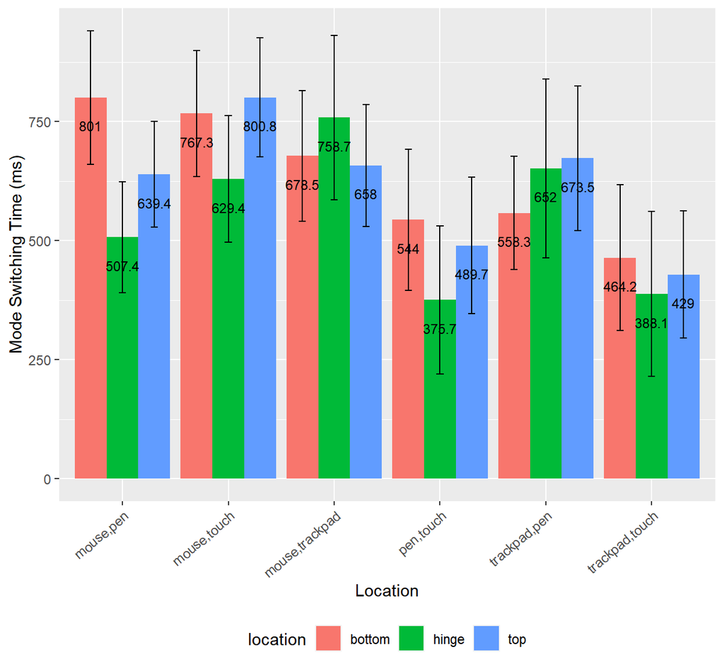

```r
ggplot(data=filter(data.ms.stats.loc, task == 'task'), aes(x=condition, y=mMTB, fill=location)) +
  geom_bar(stat="identity", position = position_dodge()) +
  geom_errorbar(aes(ymin = clMTB, ymax = cuMTB), width = 0.2, size = .5, position = position_dodge(0.9)) +
  geom_text(aes(label=round(mMTB,digits=1)), size = 3, position = position_dodge(0.9), vjust = 3.2) +
  scale_x_discrete(name="Location") +
  scale_y_continuous(name="Mode Switching Time (ms)") +
  theme(axis.text.x = element_text(angle = 40, vjust = 1, hjust=1),
        legend.position = 'bottom')
```

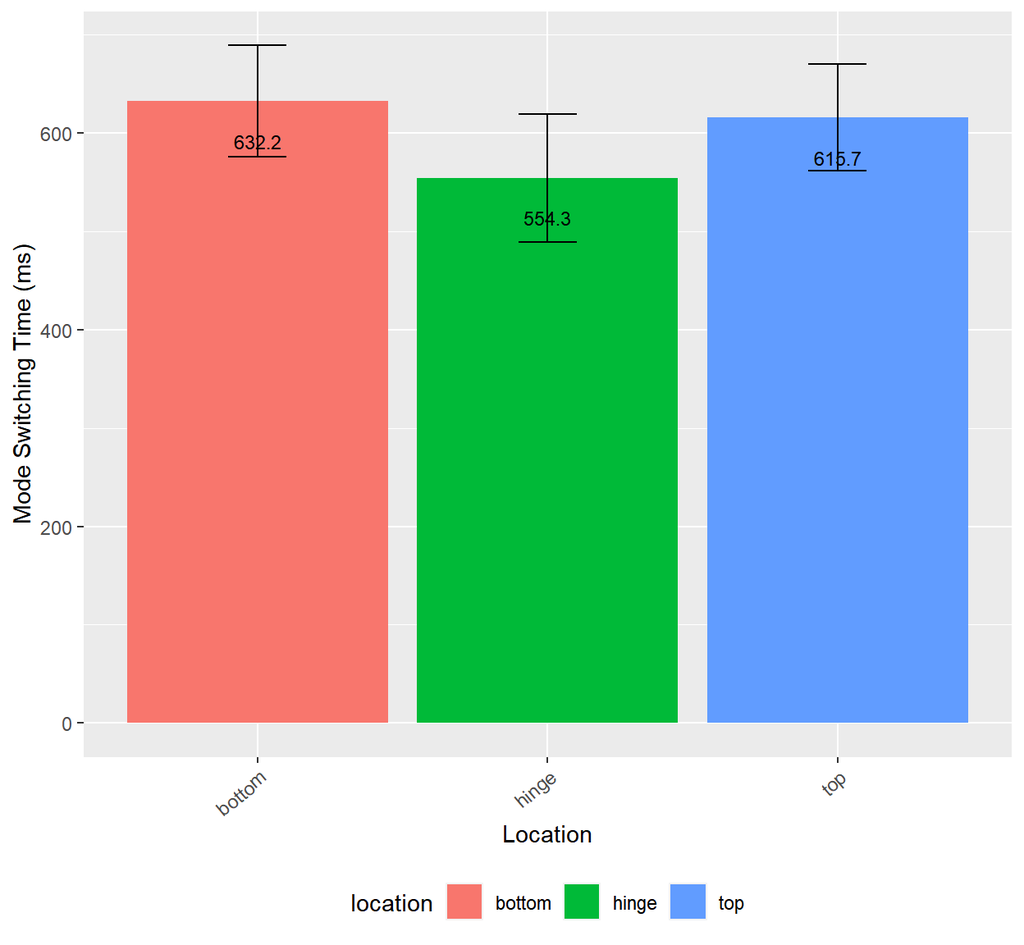

```r
ggplot(data=filter(data.ms.stats.loc2, task == 'task'), aes(x=location, y=mMTB, fill=location)) +
  geom_bar(stat="identity", position = position_dodge()) +
  geom_errorbar(aes(ymin = clMTB, ymax = cuMTB), width = 0.2, size = .5, position = position_dodge(0.9)) +
  geom_text(aes(label=round(mMTB,digits=1)), size = 3, position = position_dodge(0.9), vjust = 3.2) +
  scale_x_discrete(name="Location") +
  scale_y_continuous(name="Mode Switching Time (ms)") +
  theme(axis.text.x = element_text(angle = 40, vjust = 1, hjust=1),
        legend.position = 'bottom')
```

## 5.6 Effect of Task & Mode Switching Devices

### 5.6.1 Normality Check

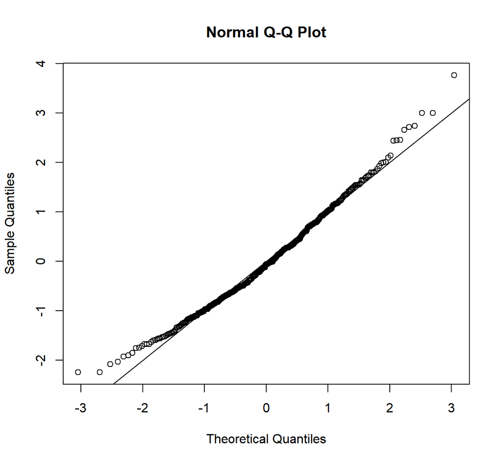

```r
m <- aov(meanMSTimeB ~ block*condition*location, data=filter(data.ms.loc, task == 'task'))
pander(normalCheck(m))
```

Shapiro-Wilk normality test

data: res W = 0.98598, p-value = 0.0003494

Shapiro-Wilk normality test: `res`

| Test statistic | P value |
| --- | --- |
| 0.986 | 0.0003494 * * * |

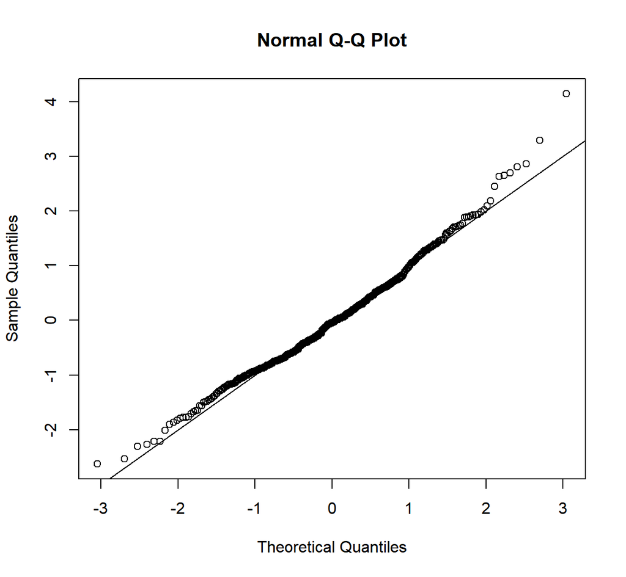

```r
m <- aov(meanMSTimeB ~ block*location, data=filter(data.ms.loc, task == 'task'))
pander(normalCheck(m))
```

Shapiro-Wilk normality test

data: res W = 0.98717, p-value = 0.0007422

Shapiro-Wilk normality test: `res`

| Test statistic | P value |
| --- | --- |
| 0.9872 | 0.0007422 * * * |

Can’t run Box-Cox due to negative mode switching times.

### 5.6.2 ANOVAs on ART Data

```r
a = art(meanMSTimeB ~ condition*location*block + Error(participantNo), data=filter(data.ms.loc, task == 'task'))
anova(a)
```

```
## Analysis of Variance of Aligned Rank Transformed Data
##
## Table Type: Repeated Measures Analysis of Variance Table (Type I)
## Model: Repeated Measures (aov)
## Response: art(meanMSTimeB)
##
##                            Error Df Df.res F value     Pr(>F)
## 1 condition                Withn  5    385 6.54627 7.3416e-06 ***
## 2 location                 Withn  2    385 1.15794    0.31522
## 3 block                    Withn  1    385 0.47666    0.49036
## 4 condition:location       Withn 10    385 1.06772    0.38619
## 5 condition:block          Withn  5    385 1.02728    0.40114
## 6 location:block           Withn  2    385 1.53692    0.21636
## 7 condition:location:block Withn 10    385 0.30246    0.98037
## ---
## Signif. codes:   0 '***' 0.001 '**' 0.01 '*' 0.05 '.' 0.1 ' ' 1
```

```r
a = art(meanMSTimeB ~ location*block + Error(participantNo), data=filter(data.ms.loc, task == 'task'))
anova(a)
```

```
## Analysis of Variance of Aligned Rank Transformed Data
##
## Table Type: Repeated Measures Analysis of Variance Table (Type I)
## Model: Repeated Measures (aov)
## Response: art(meanMSTimeB)
##
##                  Error Df Df.res F value  Pr(>F)
## 1 location       Withn  2    415  1.1630 0.31358
## 2 block          Withn  1    415  0.5063 0.47715
## 3 location:block Withn  2    415  1.7481 0.17538
## ---
## Signif. codes:   0 '***' 0.001 '**' 0.01 '*' 0.05 '.' 0.1 ' ' 1
```

### 5.6.3 Post-Hoc Comparisons

```r
art.con(a, "location") %>% summary() %>% mutate(sig = ifelse(p.value < 0.05, "*", ""))
```

```
##  contrast       estimate   SE  df t.ratio p.value sig
##  bottom - hinge   16.403 12.1 415   1.359  0.3634
##  bottom - top      0.972 12.1 415   0.081  0.9964
##  hinge - top     -15.431 12.1 415  -1.279  0.4080
##
## Results are averaged over the levels of: block
## P value adjustment: tukey method for comparing a family of 3 estimates
```